# Exploration_Hari

```python
print("Total dataset setelah dihapus dengan metode IQR", len(dataset_iqr))
print("Total dataset setelah dihapus dengan metode Z-Score", len(dataset_zin))
```

```
Total dataset setelah dihapus dengan metode IQR 5415
Total dataset setelah dihapus dengan metode Z-Score 7309
```

```python
#Berdasarkan data diatas kami menggunakan IQR  sebagai acuan Metode penghapusan Outliers
dataset = dataset_iqr
dataset
```

|  | brand | category | rating | number_of_reviews | love | price | value_price | exclusive |
| --- | --- | --- | --- | --- | --- | --- | --- | --- |
| 0 | SEPHORA COLLECTION | no category | 5.0 | 46.0 | 0.0 | 50.0 | 50.0 | 0 |
| 5 | Givenchy | Perfume | 4.5 | 94.0 | 3000.0 | 78.0 | 78.0 | 0 |
| 6 | BVLGARI | Cologne | 5.0 | 31.0 | 3300.0 | 94.0 | 94.0 | 0 |
| 7 | Yves Saint Laurent | Perfume | 4.5 | 164.0 | 4200.0 | 62.0 | 62.0 | 0 |
| 8 | Carolina Herrera | Perfume | 4.5 | 127.0 | 2900.0 | 86.0 | 86.0 | 0 |
| ... | ... | ... | ... | ... | ... | ... | ... | ... |
| 7993 | VOLUSPA | Candles & Home Scents | 4.0 | 14.0 | 3200.0 | 18.0 | 18.0 | 0 |
| 7994 | VOLUSPA | Candles | 5.0 | 1.0 | 92.0 | 85.0 | 85.0 | 0 |
| 7996 | TOM FORD | Lipstick | 4.0 | 30.0 | 12400.0 | 55.0 | 55.0 | 0 |
| 7997 | FENTY BEAUTY by Rihanna | Lip Sets | 4.5 | 22.0 | 12900.0 | 29.0 | 34.0 | 1 |
| 7998 | tarte | Mascara | 4.5 | 5.0 | 2400.0 | 12.0 | 12.0 | 0 |

5415 rows × 8 columns

**Feature Transformation**

```python
from sklearn.preprocessing import StandardScaler
dataset_scaled = dataset
features_to_scale = ['rating', 'love', 'price', 'value_price', 'number_of_reviews']
scaler = StandardScaler()
dataset_scaled[features_to_scale] = scaler.fit_transform(dataset_scaled[features_to_scale])

dataset_scaled
```

|  | brand | category | rating | number_of_reviews | love | price | value_price | exclusive |
| --- | --- | --- | --- | --- | --- | --- | --- | --- |
| 0 | SEPHORA COLLECTION | no category | 1.805156 | -0.393898 | -0.982128 | 0.429433 | 0.390336 | 0 |
| 5 | Givenchy | Perfume | 0.647264 | 0.016475 | -0.580239 | 1.626904 | 1.562574 | 0 |
| 6 | BVLGARI | Cologne | 1.805156 | -0.522139 | -0.540050 | 2.311174 | 2.232425 | 0 |
| 7 | Yves Saint Laurent | Perfume | 0.647264 | 0.614936 | -0.419483 | 0.942635 | 0.892724 | 0 |
| 8 | Carolina Herrera | Perfume | 0.647264 | 0.298607 | -0.593635 | 1.969039 | 1.897500 | 0 |
| ... | ... | ... | ... | ... | ... | ... | ... | ... |
| 7993 | VOLUSPA | Candles & Home Scents | -0.510627 | -0.667480 | -0.553446 | -0.939105 | -0.949365 | 0 |
| 7994 | VOLUSPA | Candles | 1.805156 | -0.778623 | -0.969804 | 1.926272 | 1.855634 | 0 |
| 7996 | TOM FORD | Lipstick | -0.510627 | -0.530689 | 0.679014 | 0.643267 | 0.599664 | 0 |
| 7997 | FENTY BEAUTY by Rihanna | Lip Sets | 0.647264 | -0.599084 | 0.745995 | -0.468670 | -0.279514 | 1 |
| 7998 | tarte | Mascara | 0.647264 | -0.744425 | -0.660617 | -1.195706 | -1.200559 | 0 |

5415 rows × 8 columns

**Feature Encoding**

```python
#Dengan asumsi membuat multiclass prediction menggunakan kolom category dan karena category nya banyak kita buat saja one ot encoding agar menjadi dua kelas
# dataset.drop('label', axis=1)
dataset_labeled = pd.get_dummies(dataset, columns=['category'], prefix='category')
dataset_labeled.columns.tolist()
```

```
['brand',
 'rating',
 'number_of_reviews',
 'love',
 'price',
 'value_price',
 'exclusive',
 'label',
 'category_After Sun Care',
 'category_Aftershave',
 'category_Anti-Aging',
 'category_BB & CC Cream',
 'category_BB & CC Creams',
 'category_Bath & Body',
 'category_Bath & Shower',
 'category_Bath Soaks & Bubble Bath',
 'category_Beauty Supplements',
 'category_Blemish & Acne Treatments',
 'category_Blotting Papers',
 'category_Blush',
 'category_Body Lotions & Body Oils',
 'category_Body Mist & Hair Mist',
 'category_Body Moisturizers',
 'category_Body Products',
 'category_Body Sprays & Deodorant',
 'category_Body Sunscreen',
 'category_Body Wash & Shower Gel',
 'category_Bronzer',
 'category_Brush Cleaners',
 'category_Brush Sets',
 'category_Candles',
 'category_Candles & Home Scents',
 'category_Cellulite & Stretch Marks',
 'category_Cheek Palettes',
 'category_Cleansing Brushes',
 'category_Cologne',
 'category_Cologne Gift Sets',
 'category_Color Care',
 'category_Color Correct',
 'category_Concealer',
```

[output cut: 92 more lines]

```
 'category_Shampoo',
 'category_Shampoo & Conditioner',
 'category_Shaving',
 'category_Sheet Masks',
 'category_Skincare',
 'category_Skincare Sets',
 'category_Spa Tools',
 'category_Sponges & Applicators',
 'category_Sunscreen',
 'category_Teeth Whitening',
 'category_Tinted Moisturizer',
 'category_Toners',
 'category_Tweezers & Eyebrow Tools',
 'category_Value & Gift Sets',
 'category_no category']
```

```python
dataset_labeled
```

|  | brand | rating | number_of_reviews | love | price | value_price | exclusive | label | category_After Sun Care | category_Aftershave | ... | category_Skincare Sets | category_Spa Tools | category_Sponges & Applicators | category_Sunscreen | category_Teeth Whitening | category_Tinted Moisturizer | category_Toners | category_Tweezers & Eyebrow Tools | category_Value & Gift Sets | category_no category |
| --- | --- | --- | --- | --- | --- | --- | --- | --- | --- | --- | --- | --- | --- | --- | --- | --- | --- | --- | --- | --- | --- |
| 0 | SEPHORA COLLECTION | 1.805156 | -0.393898 | -0.982128 | 0.429433 | 0.390336 | 0 | 218 | 0 | 0 | ... | 0 | 0 | 0 | 0 | 0 | 0 | 0 | 0 | 0 | 1 |
| 5 | Givenchy | 0.647264 | 0.016475 | -0.580239 | 1.626904 | 1.562574 | 0 | 97 | 0 | 0 | ... | 0 | 0 | 0 | 0 | 0 | 0 | 0 | 0 | 0 | 0 |
| 6 | BVLGARI | 1.805156 | -0.522139 | -0.540050 | 2.311174 | 2.232425 | 0 | 20 | 0 | 0 | ... | 0 | 0 | 0 | 0 | 0 | 0 | 0 | 0 | 0 | 0 |
| 7 | Yves Saint Laurent | 0.647264 | 0.614936 | -0.419483 | 0.942635 | 0.892724 | 0 | 278 | 0 | 0 | ... | 0 | 0 | 0 | 0 | 0 | 0 | 0 | 0 | 0 | 0 |
| 8 | Carolina Herrera | 0.647264 | 0.298607 | -0.593635 | 1.969039 | 1.897500 | 0 | 41 | 0 | 0 | ... | 0 | 0 | 0 | 0 | 0 | 0 | 0 | 0 | 0 | 0 |
| ... | ... | ... | ... | ... | ... | ... | ... | ... | ... | ... | ... | ... | ... | ... | ... | ... | ... | ... | ... | ... | ... |
| 7993 | VOLUSPA | -0.510627 | -0.667480 | -0.553446 | -0.939105 | -0.949365 | 0 | 261 | 0 | 0 | ... | 0 | 0 | 0 | 0 | 0 | 0 | 0 | 0 | 0 | 0 |
| 7994 | VOLUSPA | 1.805156 | -0.778623 | -0.969804 | 1.926272 | 1.855634 | 0 | 261 | 0 | 0 | ... | 0 | 0 | 0 | 0 | 0 | 0 | 0 | 0 | 0 | 0 |
| 7996 | TOM FORD | -0.510627 | -0.530689 | 0.679014 | 0.643267 | 0.599664 | 0 | 244 | 0 | 0 | ... | 0 | 0 | 0 | 0 | 0 | 0 | 0 | 0 | 0 | 0 |
| 7997 | FENTY BEAUTY by Rihanna | 0.647264 | -0.599084 | 0.745995 | -0.468670 | -0.279514 | 1 | 86 | 0 | 0 | ... | 0 | 0 | 0 | 0 | 0 | 0 | 0 | 0 | 0 | 0 |
| 7998 | tarte | 0.647264 | -0.744425 | -0.660617 | -1.195706 | -1.200559 | 0 | 297 | 0 | 0 | ... | 0 | 0 | 0 | 0 | 0 | 0 | 0 | 0 | 0 | 0 |

5415 rows × 147 columns

# Handle class imbalance

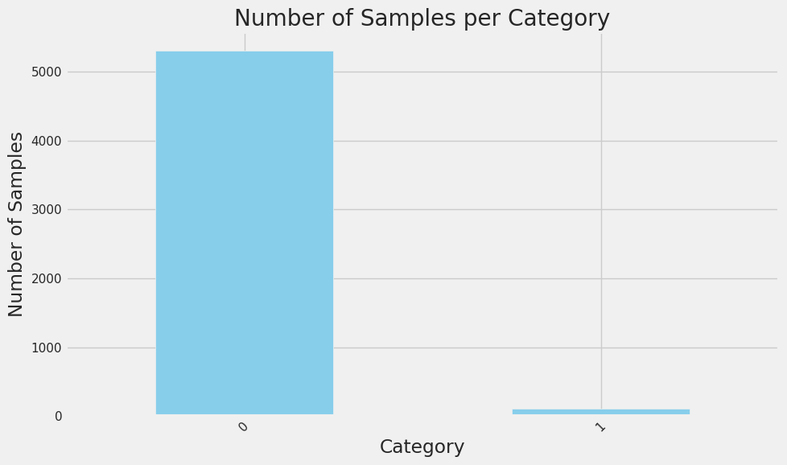

```python
class_counts = dataset_labeled['category_Conditioner'].value_counts()

plt.figure(figsize=(10, 6))
class_counts.plot(kind='bar', color='skyblue')
plt.xlabel('Category')
plt.ylabel('Number of Samples')
plt.title('Number of Samples per Category')
plt.xticks(rotation=45)  # Rotasi label kategori agar lebih mudah dibaca
plt.tight_layout()
plt.show()
```

Terlihat jelas bahwa kelas 0 mayoritas dan kelas 1 minoritas artinya banyak produk bukan kategori Condisioner

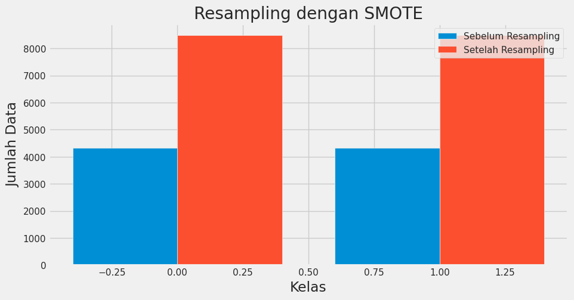

```python
from imblearn.over_sampling import SMOTE
from imblearn.combine import SMOTEENN, SMOTETomek
from imblearn.under_sampling import RandomUnderSampler,EditedNearestNeighbours, TomekLinks
from sklearn.model_selection import train_test_split

X = dataset_labeled[['rating','number_of_reviews','love','price','value_price','exclusive']]
y = dataset_labeled[['category_Conditioner']]

# Lakukan train-test split dan jangan pernah melakukan smote pada data testing karena dapat membuat model BIAS
X_train, X_test, y_train, y_test = train_test_split(X, y, test_size=0.2, random_state=42)

smote = SMOTE(random_state=42)
X_resampled, y_resampled = smote.fit_resample(X_train, y_train)

# Hitung jumlah data pada setiap kelas sebelum dan setelah resampling
class_counts_before = [len(y_train[y_train == i]) for i in np.unique(y_train)]
class_counts_after = [len(y_resampled[y_resampled == i]) for i in np.unique(y_resampled)]

# Labels untuk kelas
class_labels = np.unique(y_train)

# Membuat plot
plt.figure(figsize=(10, 5))
plt.bar(class_labels - 0.2, class_counts_before, width=0.4, align='center', label='Sebelum Resampling')
plt.bar(class_labels + 0.2, class_counts_after, width=0.4, align='center', label='Setelah Resampling')
plt.xlabel('Kelas')
plt.ylabel('Jumlah Data')
plt.title('Resampling dengan SMOTE')
plt.legend()
plt.show()
```

Metode yang kita gunakan adalah SMOTE yaitu menciptakan kelas baru berdasarkan kelas yang ada pada data sehingga jumlah kelas sama

# 5. Feature Engineering

Cek feature yang ada sekarang, lalu lakukan:

1. Feature selection (membuang feature yang kurang relevan atau redundan)
2. Feature extraction (membuat feature baru dari feature yang sudah ada)
3. Tuliskan minimal 4 feature tambahan (selain yang sudah tersedia di dataset) yang mungkin akan sangat membantu membuat performansi model semakin bagus (ini hanya ide saja, untuk menguji kreativitas teman-teman, tidak perlu benar-benar dicari datanya dan tidak perlu diimplementasikan)

Untuk 2A & 2B, tetap tuliskan jika memang tidak bisa dilakukan (contoh: “Semua feature digunakan untuk modelling (tidak ada yang dihapus), karena semua feature relevan”)

**Feature Selection**

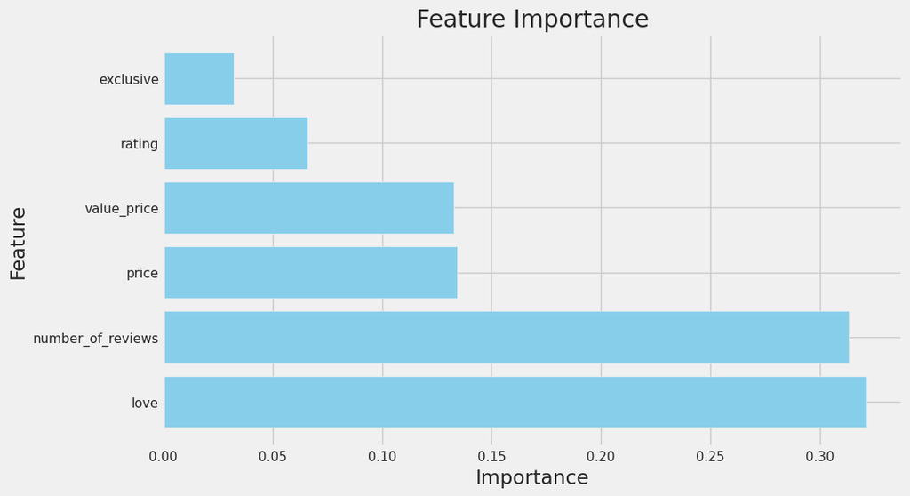

```python
from sklearn.ensemble import RandomForestClassifier

# Buat model Random Forest
rf_model = RandomForestClassifier()

X
# Latih model pada data latih
rf_model.fit(X, y)

# Dapatkan feature importance
feature_importance = rf_model.feature_importances_

# Simpan hasil feature importance ke dalam DataFrame untuk visualisasi
feature_importance_df = pd.DataFrame({'Feature': X.columns, 'Importance': feature_importance})

# Urutkan berdasarkan nilai importance secara menurun
feature_importance_df = feature_importance_df.sort_values(by='Importance', ascending=False)

# Visualisasikan feature importance
plt.figure(figsize=(10, 6))
plt.barh(feature_importance_df['Feature'], feature_importance_df['Importance'], color='skyblue')
plt.xlabel('Importance')
plt.ylabel('Feature')
plt.title('Feature Importance')
plt.show()
```

Untuk mendukung hasil analisa pada soal sebelum nya bahwa kami merekomendasikan untuk menhapus kolom price / value price karena memiliki kesamaan terlihat pada barchart horizontal diatas nilai range nya hampir sejajar.

**Feature extraction**

```python
from sklearn.decomposition import PCA
dataset_labeled_pca = dataset_labeled
X = dataset_labeled[['price', 'value_price']]
pca = PCA(n_components=1)
X_pca = pca.fit_transform(X)
dataset_labeled_pca['harga_pca'] = X_pca

dataset_labeled_pca = dataset_labeled_pca[['rating','number_of_reviews','love','exclusive','harga_pca','category_Conditioner']]
dataset_labeled_pca
```

|  | rating | number_of_reviews | love | exclusive | harga_pca | category_Conditioner |
| --- | --- | --- | --- | --- | --- | --- |
| 0 | 1.805156 | -0.393898 | -0.982128 | 0 | 0.579664 | 0 |
| 5 | 0.647264 | 0.016475 | -0.580239 | 0 | 2.255302 | 0 |
| 6 | 1.805156 | -0.522139 | -0.540050 | 0 | 3.212809 | 0 |
| 7 | 0.647264 | 0.614936 | -0.419483 | 0 | 1.297795 | 0 |
| 8 | 0.647264 | 0.298607 | -0.593635 | 0 | 2.734056 | 0 |
| ... | ... | ... | ... | ... | ... | ... |
| 7993 | -0.510627 | -0.667480 | -0.553446 | 0 | -1.335350 | 0 |
| 7994 | 1.805156 | -0.778623 | -0.969804 | 0 | 2.674211 | 0 |
| 7996 | -0.510627 | -0.530689 | 0.679014 | 0 | 0.878885 | 0 |
| 7997 | 0.647264 | -0.599084 | 0.745995 | 1 | -0.529046 | 0 |
| 7998 | 0.647264 | -0.744425 | -0.660617 | 0 | -1.694415 | 0 |

5415 rows × 6 columns

PCA digunakan untuk mengurangi dimensi dari dua fitur 'price' dan 'value_price' menjadi satu fitur baru 'harga_pca'. Kemudian, hasil PCA dimasukkan kembali ke dalam DataFrame sebagai fitur baru

**Pengujian Machine Learning Menggunakan Beberapa Model**

```python
feature =  dataset_labeled_pca[['rating','number_of_reviews','love','exclusive','harga_pca']]
label = dataset_labeled_pca[['category_Conditioner']]

X_train, X_test, y_train, y_test = train_test_split(feature, label, test_size=0.3,random_state=0)

undersampler = RandomUnderSampler(random_state=42)
X_train_resampled, y_train_resampled = undersampler.fit_resample(X_train, y_train)


from sklearn.ensemble import RandomForestClassifier
from sklearn.svm import SVC
from sklearn.metrics import classification_report

#RF
rf_model = RandomForestClassifier(random_state=0)
rf_model.fit(X_train_resampled, y_train_resampled)
rf_predictions = rf_model.predict(X_test)


# SVM
svm_model = SVC(random_state=0)
svm_model.fit(X_train_resampled, y_train_resampled)
svm_predictions = svm_model.predict(X_test)

# Output classification report untuk RF
print("Classification Report for Random Forest:")
print(classification_report(y_test, rf_predictions))

# Output classification report untuk SVM
print("Classification Report for SVM:")
print(classification_report(y_test, svm_predictions))
```

```
Classification Report for Random Forest:
              precision    recall  f1-score   support

           0       0.99      0.63      0.77      1588
           1       0.05      0.81      0.09        37

    accuracy                           0.64      1625
   macro avg       0.52      0.72      0.43      1625
weighted avg       0.97      0.64      0.76      1625

Classification Report for SVM:
              precision    recall  f1-score   support

           0       0.99      0.58      0.73      1588
           1       0.04      0.84      0.08        37

    accuracy                           0.58      1625
   macro avg       0.52      0.71      0.41      1625
weighted avg       0.97      0.58      0.72      1625
```

```python
#@title Convert ipynb to HTML in Colab
# Upload ipynb
from google.colab import files
f = files.upload()

# Convert ipynb to html
import subprocess
file0 = list(f.keys())[0]
_ = subprocess.run(["pip", "install", "nbconvert"])
_ = subprocess.run(["jupyter", "nbconvert", file0, "--to", "html"])

# download the html
files.download(file0[:-5]+"html")
```

Upload widget is only available when the cell has been executed in the current browser session. Please rerun this cell to enable.